# R bootcamp, Module 4: Calculations

August 2022, UC Berkeley

Alan Aw

# Vectorized calculations and comparisons

At the core of R is the idea of doing calculations on entire vectors.

```r
## Vectorized arithmetic
gdpTotal <- gapminder$gdpPercap * gapminder$pop

## Vectorized comparisons
wealthy <- gapminder2007$gdpPercap >= 30000

vec1 <- rnorm(5)
vec2 <- rnorm(5)
vec1 > vec2
```

```
## [1] FALSE FALSE  TRUE  TRUE FALSE
```

```r
## Vectorized boolean operations
vec1 == vec2
```

```
## [1] FALSE FALSE FALSE FALSE FALSE
```

```r
vec1 != vec2
```

```
## [1] TRUE TRUE TRUE TRUE TRUE
```

```r
## careful:
vec1 = vec2
identical(vec1, vec2)
```

```
## [1] TRUE
```

```r
## using 'or'
gdpSubset >= 100000 | gdpSubset <= 1000
```

```
## Error in eval(expr, envir, enclos): object 'gdpSubset' not found
```

```r
## using 'and'
gapminder$gdpPercap[1:10] >= 100000 & gapminder$continent[1:10] == "Asia"
```

```
##  [1] FALSE FALSE FALSE FALSE FALSE FALSE FALSE FALSE FALSE FALSE
```

# Recycling

An important related concept is that of recycling

```r
vec10 <- sample(1:10, 10, replace = TRUE)
vec3 <- sample(1:10, 3, replace = TRUE)
vec5 <- sample(1:10, 5, replace = TRUE)
vec10
```

```
##  [1]  4  4  2  2  9  9  5  1 10  7
```

```r
vec3
```

```
## [1] 8 6 9
```

```r
vec5
```

```
## [1] 7 5 5 7 6
```

```r
vec10 + vec5
```

```
##  [1] 11  9  7  9 15 16 10  6 17 13
```

```r
vec10 + vec3
```

```
##  [1] 12 10 11 10 15 18 13  7 19 15
```

**Question**: Tell me what’s going on. What choices were made by the R developers?

# Vectorized calculations: quick quiz

**[P](https://www.polleverywhere.com/multiple_choice_polls/UnX1ymqBWe624UwdBnnQB)OLL 4A**: 2^3 is raising 2 to the power 3, so you get 8.

(respond at https://pollev.com/chrispaciorek428)

What will this return?

`(1:4)^(1:4)`

1. an error
2. 1, 2, 3, 4
3. 1, 4, 27, 256
4. 1, 4, 9, 16
5. 1, 16, 81, 256

**[P](https://www.polleverywhere.com/multiple_choice_polls/IcuoQWyZ3IUs8A8PBH6eb)OLL 4B**: What will this return?

```
vec1 <- c(1,2,3,4)
vec2 <- c(1,2)
vec1 + vec2
```

1. 2, 4
2. 2, 4, 5, 6
3. 2, 4, 4, 6
4. an error

# Why vectorize?

As we’ve seen, R has many functions that allow you to operate on each element of a vector all at once. Here’s an example of a statistical calculation with simulated values.

Imagine how this code would look if written using a loop, or three separate loops.

```r
vals <- rnorm(1000)
chi2vals <- vals^2
chi2_df1000 <- sum(chi2vals)
```

Advantages:

- much faster than looping
- easier to code
- easier to read and understand the code

Sometimes there are surprises in terms of what is fast, as well as tricks for vectorizing things in unexpected ways:

```r
vals <- rnorm(1e6)
system.time(trunc <- ifelse(vals > 0, vals, 0))
```

```
##    user  system elapsed
##   0.026   0.008   0.034
```

```r
system.time(vals <- vals * (vals > 0))
```

```
##    user  system elapsed
##   0.004   0.000   0.004
```

**Question**: What am I doing with `vals * (vals > 0)` ? What happens behind the scenes in R?

If you use a trick like this, having a comment in your code is a good idea.

# Vectorized functions

Lots of functions in R are vectorized (i.e., they can take a single value or a vector as an input argument), such as some we’ve already used.

```r
tmp <- as.character(gapminder$year)
gapminder$year2 <- substring(tmp, 3, 4)
head(gapminder$year2)
```

```
## [1] "52" "57" "62" "67" "72" "77"
```

Question: Note the code above runs and the syntax is perfectly good R syntax, but in terms of what it does, there is a bug in it. See if you can see what it is.

# Vectorized vector/matrix calculations

## Vectorized arithmetic

Recall that `+`, `-`,`*`, `/` do vectorized calculations:

```r
A <- matrix(1:9, 3)
B <- matrix(seq(4,36, by = 4), 3)

A + B
```

```
##      [,1] [,2] [,3]
## [1,]    5   20   35
## [2,]   10   25   40
## [3,]   15   30   45
```

```r
A + B[ , 1]
```

```
##      [,1] [,2] [,3]
## [1,]    5    8   11
## [2,]   10   13   16
## [3,]   15   18   21
```

```r
A * B
```

```
##      [,1] [,2] [,3]
## [1,]    4   64  196
## [2,]   16  100  256
## [3,]   36  144  324
```

```r
A * B[ , 1]
```

```
##      [,1] [,2] [,3]
## [1,]    4   16   28
## [2,]   16   40   64
## [3,]   36   72  108
```

## Linear algebra: Matrix/vector multiplication

```r
A %*% B[ , 1]
```

```
##      [,1]
## [1,]  120
## [2,]  144
## [3,]  168
```

```r
A %*% B
```

```
##      [,1] [,2] [,3]
## [1,]  120  264  408
## [2,]  144  324  504
## [3,]  168  384  600
```

```r
identical(t(A)%*%A, crossprod(A))
```

```
## [1] TRUE
```

# Linear algebra (optional)

R can do essentially any linear algebra you need. It uses system-level packages called BLAS (basic linear algebra subroutines) and LAPACK (linear algebra package). Note that these calculations will be essentially as fast as if you wrote C code because R just calls C and Fortran routines to do the calculations.

The BLAS that comes with R is fairly slow. It’s possible to use a faster BLAS, as well as one that uses multiple cores automatically. This can in some cases give you an order of magnitude speedup if your work involves a lot of matrix manipulations/linear algebra. More details in Module 10.

# (Advanced) Matrix decompositions

Here are some examples of common matrix decompositions: Cholesky decomposition, eigenvalues/eigenvectors, and SVD. These all use BLAS+LAPACK.

```r
## next 3 lines generate a positive definite matrix
library(fields)
times <- seq(0, 1, length = 100)
R <- exp(-rdist(times) / 0.2) # a correlation matrix
######################################################
e <- eigen(R)
range(e$values)
```

```
## [1]  0.02525338 32.85537225
```

```r
e$vectors[ , 1]
```

```
##   [1] 0.05195413 0.05448567 0.05698864 0.05946173 0.06190363 0.06431308
##   [7] 0.06668879 0.06902954 0.07133409 0.07360123 0.07582978 0.07801856
##  [13] 0.08016643 0.08227226 0.08433494 0.08635341 0.08832659 0.09025345
##  [19] 0.09213298 0.09396420 0.09574615 0.09747789 0.09915851 0.10078713
##  [25] 0.10236291 0.10388500 0.10535262 0.10676499 0.10812137 0.10942106
##  [31] 0.11066337 0.11184765 0.11297327 0.11403965 0.11504623 0.11599249
##  [37] 0.11687791 0.11770205 0.11846447 0.11916476 0.11980256 0.12037754
##  [43] 0.12088940 0.12133786 0.12172270 0.12204370 0.12230071 0.12249358
##  [49] 0.12262222 0.12268655 0.12268655 0.12262222 0.12249358 0.12230071
##  [55] 0.12204370 0.12172270 0.12133786 0.12088940 0.12037754 0.11980256
##  [61] 0.11916476 0.11846447 0.11770205 0.11687791 0.11599249 0.11504623
##  [67] 0.11403965 0.11297327 0.11184765 0.11066337 0.10942106 0.10812137
##  [73] 0.10676499 0.10535262 0.10388500 0.10236291 0.10078713 0.09915851
##  [79] 0.09747789 0.09574615 0.09396420 0.09213298 0.09025345 0.08832659
##  [85] 0.08635341 0.08433494 0.08227226 0.08016643 0.07801856 0.07582978
##  [91] 0.07360123 0.07133409 0.06902954 0.06668879 0.06431308 0.06190363
##  [97] 0.05946173 0.05698864 0.05448567 0.05195413
```

```r
sv <- svd(R)
U <- chol(R)

devs <- rnorm(100)
Rinvb <- solve(R, devs)  # R^{-1} b
Rinv <- solve(R) # R^{-1} -- try to avoid this
```

# Pre-allocation

This is slow.

```r
vals <- 0
n <- 50000
system.time({
for(i in 1:n)
      vals <- c(vals, i)
})
```

```
##    user  system elapsed
##   2.945   0.007   2.954
```

The same holds for using `rbind()`, `cbind()`, or adding to a list, one element at a time.

**Question**: Thoughts on why this are so slow? Think about what R might be doing behind the scenes.

**Note**: This is one area where Python and some other languages handle the situation in a more sophisticated way.

# The answer is to pre-allocate memory

This is not so slow. (Please ignore the for-loop hypocrisy and the fact that I could do this as `vals <- 1:n`.)

```r
n <- 50000
system.time({
vals <- rep(0, n)
# alternatively: vals <- as.numeric(NA); length(vals) <- n
for(i in 1:n)
      vals[i] <- i
})
```

```
##    user  system elapsed
##   0.027   0.001   0.027
```

Here’s how to pre-allocate an empty list:

```r
vals <- list(); length(vals) <- n
head(vals)
```

[output not shown]

# apply

Some functions aren’t vectorized, or you may want to use a function on every row or column of a matrix/data frame, every element of a list, etc.

For this we use the `apply()` family of functions.

```r
mat <- matrix(rnorm(100*1000), nr = 100)
row_min <- apply(mat, MARGIN = 1, FUN = min)
col_max <- apply(mat, MARGIN = 2, FUN = max)
```

There are actually some even faster specialized functions:

```r
row_mean <- rowMeans(mat)
col_sum <- colSums(mat)
```

# `lapply()` and `sapply()`

These are ‘map’ operations that apply a function to each element of a list.

```r
myList <- list(rnorm(3), rnorm(3), rnorm(5))
lapply(myList, min)
```

```
## [[1]]
## [1] -0.280493
##
## [[2]]
## [1] -0.07862098
##
## [[3]]
## [1] -1.474092
```

```r
sapply(myList, min)
```

```
## [1] -0.28049304 -0.07862098 -1.47409165
```

Note that we don’t generally want to use `apply()` on a data frame.

Recall that a dataframe is a list, hence this works:

```r
sapply(gapminder, class)
```

```
##     country   continent        year     lifeExp         pop   gdpPercap
##    "factor"    "factor"   "integer"   "numeric"   "integer"   "numeric"
##       year2
## "character"
```

# `lapply()` and `sapply()` with vectors

You can use `lapply()` and `sapply()` on regular vectors, such as vectors of indices, which can come in handy. This is a bit silly but it illustrates the idea:

```r
myfun <- function(i) {
   max(rnorm(100))
}

out <- lapply(1:6, myfun)
out
```

```
## [[1]]
## [1] 2.376375
##
## [[2]]
## [1] 2.164874
##
## [[3]]
## [1] 2.816697
##
## [[4]]
## [1] 1.717506
##
## [[5]]
## [1] 3.356898
##
## [[6]]
## [1] 3.28338
```

```r
## Or, 'in-line' the function:
```

```r
out <- sapply(1:10, function(x) x^2)
out
```

```
##  [1]   1   4   9  16  25  36  49  64  81 100
```

**[P](https://www.polleverywhere.com/multiple_choice_polls/FnXK4VqjXAnHT0ZZbMXNG)OLL 4C**: What do you think this will return:

(respond at https://pollev.com/chrispaciorek428)

```
sapply(1:6, function(n) rnorm(n))
```

1. a list, like lapply
2. a vector of 21 (1+2+3+4+5+6) elements
3. an error

# And more `apply()`s (optional)

There are a bunch of `apply()` variants, as well as parallelized versions of them:

- `tapply()`, `vapply()`, `mapply()`, `rapply()`, `eapply()`
- for parallelized versions see Module 10 or `?clusterApply`

# Tabulation

- Sometimes we need to do some basic checking for the number of observations or types of observations in our dataset
- To do this quickly and easily, `table()` is our friend

```r
tbl <- table(gapminder$country, gapminder$continent)
head(tbl)
```

```
##
##               Africa Americas Asia Europe Oceania
##   Afghanistan      0        0   12      0       0
##   Albania          0        0    0     12       0
##   Algeria         12        0    0      0       0
##   Angola          12        0    0      0       0
##   Argentina        0       12    0      0       0
##   Australia        0        0    0      0      12
```

```r
rowSums(tbl)[1:20]
```

```
##            Afghanistan                Albania                Algeria
##                     12                     12                     12
##                 Angola              Argentina              Australia
##                     12                     12                     12
##                Austria                Bahrain             Bangladesh
##                     12                     12                     12
##                Belgium                  Benin                Bolivia
##                     12                     12                     12
## Bosnia and Herzegovina               Botswana                 Brazil
##                     12                     12                     12
##               Bulgaria           Burkina Faso                Burundi
##                     12                     12                     12
##               Cambodia               Cameroon
##                     12                     12
```

```r
## Here we do a data validity check: all countries should have 12 obs in the same continent
all(rowSums(tbl) == 12)
```

```
## [1] TRUE
```

# Discretization

You may need to discretize a continuous variable [or a discrete variable with many levels], e.g., by life expectancy.

We can use `cut` to do it:

```r
gapminder2007$lifeExpBin <- cut(gapminder2007$lifeExp,
                                breaks = c(0, 40, 50, 60, 70, 75, 80, Inf))
tbl <- table(gapminder2007$continent, gapminder2007$lifeExpBin)
round( prop.table(tbl, margin = 1), 2 )
```

```
##
##            (0,40] (40,50] (50,60] (60,70] (70,75] (75,80] (80,Inf]
##   Africa     0.02    0.33    0.42    0.10    0.12    0.02     0.00
##   Americas   0.00    0.00    0.00    0.12    0.48    0.36     0.04
##   Asia       0.00    0.03    0.06    0.24    0.39    0.18     0.09
##   Europe     0.00    0.00    0.00    0.00    0.27    0.50     0.23
##   Oceania    0.00    0.00    0.00    0.00    0.00    0.00     1.00
```

# Stratified analyses I

Often we want to do individual analyses within subsets or clusters of our data.

As a first step, we might want to just split our dataset by a stratifying variable (perhaps after using `cut` to create a categorical variable).

```r
subsets <- split(gapminder,  gapminder$year)
length(subsets)
```

```
## [1] 12
```

```r
dim(subsets[['2007']])
```

```
## [1] 142   7
```

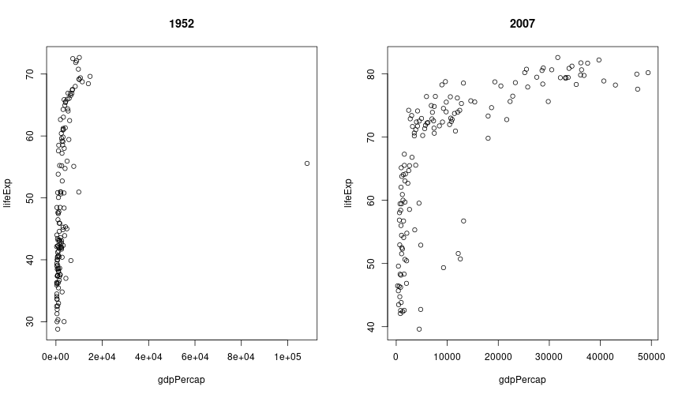

```r
par(mfrow = c(1,2))
plot(lifeExp ~ gdpPercap, data = subsets[['1952']], main = '1952')
abline(h = 0, col = 'grey')
plot(lifeExp ~ gdpPercap, data = subsets[['2007']], main = '2007')
abline(h = 0, col = 'grey')
```

Obviously, we’d want to iterate to improve that plot given the outlier.

**[P](https://www.polleverywhere.com/multiple_choice_polls/rvczm8PGtI3bD2BkcEwvu)OLL 4D**: What kind of object is produced by split, e.g.,

(respond at https://pollev.com/chrispaciorek428)

```
subsets <- split(gap,  gap$year)
```

1. a dataframe
2. a list
3. a list of lists
4. a list of dataframes
5. some new kind of object we haven’t encountered yet

# Stratified analyses I - map operations

Once you have the stratified dataset you can use `lapply` to apply a function to each item in the list.

This is known as a ‘map’ operation in other languages.

```r
meanfun <- function(sub) {
   mean(sub$lifeExp)
}

meanLifeExpByYear <- sapply(subsets, meanfun)
names(subsets)
```

```
##  [1] "1952" "1957" "1962" "1967" "1972" "1977" "1982" "1987" "1992" "1997"
## [11] "2002" "2007"
```

```r
meanLifeExpByYear
```

```
##     1952     1957     1962     1967     1972     1977     1982     1987
## 49.05762 51.50740 53.60925 55.67829 57.64739 59.57016 61.53320 63.21261
##     1992     1997     2002     2007
## 64.16034 65.01468 65.69492 67.00742
```

We’ll talk in detail about writing functions in Module 5.

# Stratified analyses II (optional)

Often we want to do individual analyses within subsets or clusters of our data. R has a variety of tools for this; for now we’ll look at `aggregate()` and `by()`. These are wrappers of `tapply()`.

## aggregate()

```r
gmSmall <- gapminder[ , c('lifeExp', 'gdpPercap')]  # reduce to only numeric columns
aggregate(gmSmall, by = list(year = gapminder$year), FUN = median, na.rm = TRUE) # na.rm not needed here but illustrates use of additional arguments to FUN
```

```
##    year lifeExp gdpPercap
## 1  1952 45.1355  1968.528
## 2  1957 48.3605  2173.220
## 3  1962 50.8810  2335.440
## 4  1967 53.8250  2678.335
## 5  1972 56.5300  3339.129
## 6  1977 59.6720  3798.609
## 7  1982 62.4415  4216.228
## 8  1987 65.8340  4280.300
## 9  1992 67.7030  4386.086
## 10 1997 69.3940  4781.825
## 11 2002 70.8255  5319.805
## 12 2007 71.9355  6124.371
```

```r
aggregate(lifeExp ~ year + continent, data = gapminder, FUN = median)
```

```
##    year continent lifeExp
## 1  1952    Africa 38.8330
## 2  1957    Africa 40.5925
## 3  1962    Africa 42.6305
## 4  1967    Africa 44.6985
## 5  1972    Africa 47.0315
## 6  1977    Africa 49.2725
## 7  1982    Africa 50.7560
## 8  1987    Africa 51.6395
## 9  1992    Africa 52.4290
## 10 1997    Africa 52.7590
## 11 2002    Africa 51.2355
## 12 2007    Africa 52.9265
## 13 1952  Americas 54.7450
## 14 1957  Americas 56.0740
```

[output cut: 46 more lines]

```r
agg <- aggregate(lifeExp ~ year + continent , data = gapminder, FUN = median)
xtabs(lifeExp ~ ., data = agg)
```

```
##       continent
## year    Africa Americas    Asia  Europe Oceania
##   1952 38.8330  54.7450 44.8690 65.9000 69.2550
##   1957 40.5925  56.0740 48.2840 67.6500 70.2950
##   1962 42.6305  58.2990 49.3250 69.5250 71.0850
##   1967 44.6985  60.5230 53.6550 70.6100 71.3100
##   1972 47.0315  63.4410 56.9500 70.8850 71.9100
##   1977 49.2725  66.3530 60.7650 72.3350 72.8550
##   1982 50.7560  67.4050 63.7390 73.4900 74.2900
##   1987 51.6395  69.4980 66.2950 74.8150 75.3200
##   1992 52.4290  69.8620 68.6900 75.4510 76.9450
##   1997 52.7590  72.1460 70.2650 76.1160 78.1900
##   2002 51.2355  72.0470 71.0280 77.5365 79.7400
##   2007 52.9265  72.8990 72.3960 78.6085 80.7195
```

Notice the ‘long’ vs. ‘wide’ formats. You’ll see more about that sort of thing in Module 6.

While you can use `aggregate` for this, many people use `dplyr`, as we’ll discuss in Module 6.

## by()

`aggregate()` works fine when the output is univariate, but what about more complicated analyses than computing the median, such as fitting a set of regressions?

```r
out <- by(gapminder, gapminder$year,
    function(sub) {
      lm(lifeExp ~ log(gdpPercap), data = sub)
    }
)
length(out)
```

```
## [1] 12
```

```r
summary(out[['2007']])
```

```
##
## Call:
## lm(formula = lifeExp ~ log(gdpPercap), data = sub)
##
## Residuals:
##     Min      1Q  Median      3Q     Max
## -25.947  -2.661   1.215   4.469  13.115
##
## Coefficients:
##                Estimate Std. Error t value Pr(>|t|)
## (Intercept)      4.9496     3.8577   1.283    0.202
## log(gdpPercap)   7.2028     0.4423  16.283   <2e-16 ***
## ---
## Signif. codes:  0 '***' 0.001 '**' 0.01 '*' 0.05 '.' 0.1 ' ' 1
##
## Residual standard error: 7.122 on 140 degrees of freedom
## Multiple R-squared:  0.6544, Adjusted R-squared:  0.652
## F-statistic: 265.2 on 1 and 140 DF,  p-value: < 2.2e-16
```

```r
summary(out[['1952']])
```

```
##
## Call:
## lm(formula = lifeExp ~ log(gdpPercap), data = sub)
##
## Residuals:
##      Min       1Q   Median       3Q      Max
## -28.9571  -5.7319   0.7517   6.5770  13.7361
##
## Coefficients:
##                Estimate Std. Error t value Pr(>|t|)
## (Intercept)    -17.8457     5.0668  -3.522 0.000578 ***
## log(gdpPercap)   8.8298     0.6626  13.326  < 2e-16 ***
## ---
## Signif. codes:  0 '***' 0.001 '**' 0.01 '*' 0.05 '.' 0.1 ' ' 1
##
## Residual standard error: 8.146 on 140 degrees of freedom
## Multiple R-squared:  0.5592, Adjusted R-squared:  0.556
## F-statistic: 177.6 on 1 and 140 DF,  p-value: < 2.2e-16
```

This is handy, but it’s just slightly simpler syntax than using `split` followed by `lapply`

# Sorting

`sort()` applied to a vector does what you expect.

Sorting a matrix or dataframe based on one or more columns is a somewhat manual process, but once you get the hang of it, it’s not bad.

```r
ord <- order(gapminder$year, gapminder$lifeExp, decreasing = TRUE)
ord[1:5]
```

```
## [1]  804  672  696 1488   72
```

```r
gm_ord <- gapminder[ord, ]
head(gm_ord)
```

```
## # A tibble: 6 × 7
##   country          continent  year lifeExp       pop gdpPercap year2
##   <fct>            <fct>     <int>   <dbl>     <int>     <dbl> <chr>
## 1 Japan            Asia       2007    82.6 127467972    31656. 07
## 2 Hong Kong, China Asia       2007    82.2   6980412    39725. 07
## 3 Iceland          Europe     2007    81.8    301931    36181. 07
## 4 Switzerland      Europe     2007    81.7   7554661    37506. 07
## 5 Australia        Oceania    2007    81.2  20434176    34435. 07
## 6 Spain            Europe     2007    80.9  40448191    28821. 07
```

You could of course write your own *sort* function that uses `order()`. More in Module 5.

Or, most people probably use `dplyr::arrange`. More in Module 6.

# Joining/Merging Data

We often need to combine data across multiple data frames, merging on common fields (i.e., *keys*). In database terminology, this is a *join* operation.

Suppose that our dataset did not have ‘continent’ in it, but that we had a separate data frame that matches country to continent.

```r
# ignore the 'wizard' behind the curtain...
c2c <- unique(gapminder[ , c('country', 'continent')])
gapminderSave <- gapminder
gapminder <- gapminder[ , -which(names(gapminder) == "continent")]

# Now our gapminder dataset doesn't have continent
head(gapminder)
```

```
## # A tibble: 6 × 6
##   country      year lifeExp      pop gdpPercap year2
##   <fct>       <int>   <dbl>    <int>     <dbl> <chr>
## 1 Afghanistan  1952    28.8  8425333      779. 52
## 2 Afghanistan  1957    30.3  9240934      821. 57
## 3 Afghanistan  1962    32.0 10267083      853. 62
## 4 Afghanistan  1967    34.0 11537966      836. 67
## 5 Afghanistan  1972    36.1 13079460      740. 72
## 6 Afghanistan  1977    38.4 14880372      786. 77
```

## using `dplyr`’s join functions

The `dplyr` package (to be discussed in detail in Module 6) provides a variety of *join* operations like those used in databases.

Now let’s add the continent info in:

```r
head(c2c)
```

```
## # A tibble: 6 × 2
##   country     continent
##   <fct>       <fct>
## 1 Afghanistan Asia
## 2 Albania     Europe
## 3 Algeria     Africa
## 4 Angola      Africa
## 5 Argentina   Americas
## 6 Australia   Oceania
```

```r
head(gapminder)
```

```
## # A tibble: 6 × 6
##   country      year lifeExp      pop gdpPercap year2
##   <fct>       <int>   <dbl>    <int>     <dbl> <chr>
## 1 Afghanistan  1952    28.8  8425333      779. 52
## 2 Afghanistan  1957    30.3  9240934      821. 57
## 3 Afghanistan  1962    32.0 10267083      853. 62
## 4 Afghanistan  1967    34.0 11537966      836. 67
## 5 Afghanistan  1972    36.1 13079460      740. 72
## 6 Afghanistan  1977    38.4 14880372      786. 77
```

```r
library(dplyr)

gapminder <- inner_join(gapminder, c2c, by = "country")

dim(gapminderSave)
```

```
## [1] 1704    7
```

```r
dim(gapminder)
```

```
## [1] 1704    7
```

```r
identical(gapminderSave, gapminder)
```

```
## [1] FALSE
```

```r
identical(gapminderSave, gapminder[ , names(gapminderSave)])
```

```
## [1] TRUE
```

You can also do *left*, *right*, and *full* joins.

## Using `merge` (optional)

Alternatively, we could use the base R function, merge().

Now let’s add the continent info in:

```r
gapminder <- gapminder[ , -which(names(gapminder) == "continent")]  ## reset

head(c2c)
```

```
## # A tibble: 6 × 2
##   country     continent
##   <fct>       <fct>
## 1 Afghanistan Asia
## 2 Albania     Europe
## 3 Algeria     Africa
## 4 Angola      Africa
## 5 Argentina   Americas
## 6 Australia   Oceania
```

```r
head(gapminder)
```

```
## # A tibble: 6 × 6
##   country      year lifeExp      pop gdpPercap year2
##   <fct>       <int>   <dbl>    <int>     <dbl> <chr>
## 1 Afghanistan  1952    28.8  8425333      779. 52
## 2 Afghanistan  1957    30.3  9240934      821. 57
## 3 Afghanistan  1962    32.0 10267083      853. 62
## 4 Afghanistan  1967    34.0 11537966      836. 67
## 5 Afghanistan  1972    36.1 13079460      740. 72
## 6 Afghanistan  1977    38.4 14880372      786. 77
```

```r
gapminder <- merge(gapminder, c2c, by.x = 'country', by.y = 'country',
                   all.x = TRUE, all.y = FALSE)

dim(gapminderSave)
```

```
## [1] 1704    7
```

```r
dim(gapminder)
```

```
## [1] 1704    7
```

```r
identical(gapminderSave, gapminder)
```

```
## [1] FALSE
```

```r
identical(as.data.frame(gapminderSave), gapminder[ , names(gapminderSave)])
```

```
## [1] TRUE
```

What’s the deal with the `all.x` and `all.y`? They allow one to request the equivalent of left, right, and full joins. We can tell R whether we want to keep all of the `x` observations, all the `y` observations, or neither, or both, when there may be rows in either of the datasets that don’t match the other dataset.

# Breakout

### Basics

1. Create a vector that concatenates the country and year to create a ‘country-year’ variable in a vectorized way using the string processing functions.
2. Use `table()` to figure out the number of countries available for each continent.

### Using the ideas

3. Explain the steps of what this code is doing: `tmp <- gapminder[ , -which(names(gapminder) == "continent")]`.
4. Compute the number of NAs in each column of the gapminder dataset using `sapply()` and making use of the `is.na()` function. It’s possible to do this without writing a function (which is a topic we’ll cover in Module 5).
5. Discretize gdpPercap into some bins and create a gdpPercap_binned variable. Count the number of values in each bin.
6. Create a boxplot of life expectancy by binned gdpPercap.
7. Create a dataframe that has the total (i.e., world) population across all the countries for each year.
8. Merge the info from problem 7 back into the original gapminder dataset. Now plot life expectancy as a function of world population.
9. Suppose we have two categorical variables and we conduct a hypothesis test of independence. The chi-square statistic is:

$$\chi^2 = \sum_{i=1}^{n}\sum_{j=1}^{m} \frac{(y_{ij} - e_{ij})^2}{e_{ij}},$$

where $e_{ij} = \frac{y_{i\cdot} y_{\cdot j}}{y_{\cdot \cdot}}$, with $y_{i\cdot}$ the sum of the values in the i’th row, $y_{\cdot j}$ the sum of values in the j’th column, and $y_{\cdot\cdot}$ the sum of all the values. Suppose I give you a matrix in R with the $y_{ij}$ values.

You can generate a test matrix as:

```r
y <- matrix(sample(1:10, 12, replace = TRUE),
nrow = 3, ncol = 4)
```

Compute the statistic without *any* loops as follows:

- First, assume you have the *e* matrix. How do you compute the statistic without loops as a function of `y` and `e`?
- How can you construct the *e* matrix? Hint: the numerator of *e* is just an *outer product* for which the `outer()` function can be used.

### Advanced

10. For each combination of year and continent, find the 95th percentile of life expectancy.
11. Here’s a cool trick to pull off a particular element of a list of lists:

```r
params <- list(a = list(mn = 7, sd = 3), b = list(mn = 6,sd = 1),
  c = list(mn = 2, sd = 1))
sapply(params, "[[", 1)
```

```
## a b c
## 7 6 2
```

Explain what that does and why it works.

Hint:

```r
test <- list(5, 7, 3)
test[[2]]
```

```
## [1] 7
```

```r
# `[[`(test, 2)  # need it commented or R Markdown processing messes it up...

# `+`(3, 7)
```